# Data 605 HW13: Univariate & Multivariate Calculus

Please refer to the [Assignment 13 Document](https://github.com/shirley-wong/Data-605/blob/master/Assignment13/hw13.pdf).

# 1 Problem Set 1

Use Integration by substitution to solve the integral below.

$$\int 4e^{-7x}dx$$

## 1.1 Answer

Let $F(x)=\int 4e^{-7x}dx$, $u=-7x$.

Then $du=-7dx$, $dx=\frac{du}{-7}$.

Thus,

$$\int 4e^{-7x}dx = \int \frac{4}{-7}e^{u}du$$
$$=-\frac{4}{7}e^{u}+C, \;where\;c\;is\;a\;constant.$$
$$=-\frac{4}{7}e^{-7x}+C, \;where\;c\;is\;a\;constant.$$

# 2 Problem Set 2

Biologists are treating a pond contaminated with bacteria. The level of contamination is changing at a rate of $\frac{dN}{dt} = -\frac{3150}{t^{4}}-220$ bacteria per cubic centimeter per day, where $t$ is the number of days since treatment began. Find a function $N(t)$ to estimate the level of contamination if the level after 1 day was 6530 bacteria per cubic centimeter.

## 2.1 Answer

We have,
$$N(t)-N(0) = \int_{0}^{t}(-\frac{3150}{s^{4}}-220)ds$$

$$= \int_{0}^{t}-3150s^{-4}-220ds$$
$$=\left [ -\frac{3150s^{-3}}{-3}-220s \right ]^{t}_{0}$$
$$=1050t^{-3}-220t -0+0$$
$$N(t)-N(0)=1050t^{-3}-220t$$

Given $N(1)=6530$, $N(1)-N(0)=1050-220=830$,

$$N(0)=6530-830=5700$$
Therefore,
$$N(t)=1050t^{-3}-220t+5700$$

# 3 Problem Set 3

Find the total area of the red rectangles in the figure below, where the equation of the line is $f(x)=2x-9$.

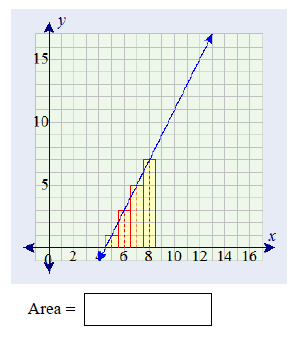

## 3.1 Answer

By looking at the graph given above, the area of the read rectangles $=1+3+5+7=16$.

By integration, the area is:

$$=\int_{4.5}^{8.5}2x-9dx$$
$$=\left [ x^{2}-9x \right ] ^{8.5}_{4.5}$$

$$=8.5^{2}-9 \cdot 8.5 - 4.5^{2} + 9 \cdot 4.5$$

$$=16$$

# 4 Problem Set 4

Find the area of the region bounded by the graphs of the given equations,
$$y = x^{2}-2x-2, y = x + 2$$

## 4.1 Answer

Graphing the two equations:

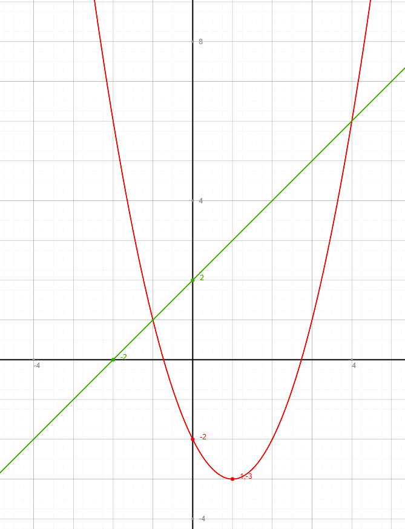

Determining the intersections:

$$x^{2}-2x-2 = x+2$$
$$x^{2}-3x-4 = 0$$
$$(x+1)(x-4)=0$$
$$x=-1\;or\;x=4$$

By integration,

$$\int_{-1}^{4}x+2-(x^{2}-2x-2)$$
$$=\int_{-1}^{4}-x^{2}+3x+4\,dx$$
$$=\left[ -\frac{x^{3}}{3}+\frac{3x^{2}}{2}+4x \right]^{4}_{-1}$$
$$=-\frac{4^{3}}{3}+\frac{3\cdot4^{2}}{2}+4^{2}-(\frac{1}{3}+\frac{3}{2}-4)$$
$$=-\frac{64}{3}+24+16-\frac{1}{3}-\frac{3}{2}+4$$
$$\approx 20.8333$$

# 5 Problem Set 5

A beauty supply store expects to sell 110 flat irons during the next year. It costs $3.75 to store one flat iron for one year. There is a fixed cost of $8.25 for each order. Find the lot size and the number of orders per year that will minimize inventory costs.

## 5.1 Answer

Let $s$ be lot size, $n$ be number of orders, $c$ be the inventory costs.

Assume half of inventory keep in stocks.

We have,

$$c = 8.25 \cdot n + 3.75 \cdot \frac{s}{2} \;\; and \;\; ns=110$$
$$c = 8.25 \cdot n + 3.75 \cdot \frac{110}{2n}$$
$$c = 8.25 \cdot n + \frac{206.25}{n}$$
$$c'=8.25-206.25\cdot n^{-2}=0$$
$$n=5$$
$$s=\frac{110}{5}=22$$
$$c=8.25 \cdot 5 +\frac{206.25}{5}=82.5$$

Therefore, to minimize the inventory costs, the lot size $22$ and number of orders $5$ can come up with the minimum inventory costs $82.50.

# 6 Problem Set 6

Use integration by parts to solve the integral below.

$$\int ln(9x)\cdot x^{6} \, dx$$

## 6.1 Answer

Let $u=ln(9x)$ and $dv=x^{6}dx$,

we have $du=\frac{1}{9x}\cdot 9dx=\frac{dx}{x}$ and $v=\frac{x^{7}}{7}$.

To solve the given equation using integration by parts,

$$\int ln(9x)\cdot x^{6} \, dx$$

$$=\int u \,dv = u \cdot v - \int v \,du$$

$$=ln(9x)\cdot\frac{x^{7}}{7} - \int \frac{x^{7}}{7} \frac{dx}{x}$$
$$=ln(9x)\cdot\frac{x^{7}}{7} - \int \frac{x^{6}}{7}dx$$
$$=ln(9x)\cdot\frac{x^{7}}{7} - \frac{x^{7}}{7\cdot7} +C$$
$$=\frac{x^{7}}{7}\cdot \left[ ln(9x)-\frac{1}{7} \right] +C$$

, where C is a constant.

# 7 Problem Set 7

Determine whether $f(x)$ is a probability density function on the interval $[1, e^{6}]$. If not, determine the value of the definite integral.
$$f(x)=\frac{1}{6x}$$

## 7.1 Answer

For a function to be a probability density function on the interval:

- requirement 1: The value must always be non-negative.
- requirement 2: The definite integral has to equal 1.

First, $f(x)=\frac{1}{6x} >0 \;\forall \;x>0,$ so the first requirement holds on the interval $[1, e^{6}]$.

Second,

$$\int_{1}^{e^{6}} \frac{1}{6x} \,dx$$
$$=\left[ \frac{ln(x)}{6} \right ] ^{e^{6}}_{1}$$
$$=\frac{ln(e^{6})}{6} - \frac{ln(1)}{6}$$
$$=1-0=1$$

$\because$ The two requirements are both met.

$\therefore$ The given function is a probability density function on the interval $[1, e^{6}]$.